# Heart Analysis

Rittika Adhikari (rittika2@illinois.edu)

Wednesday Nov 11, 2020

## Introduction

Heart disease is the leading cause of death for men, women, and people of most ethnic and racial groups in the United States of America. In fact, about 650K Americans die from heart disease every year - that’s 1 in every 4 deaths. Additionally, heart disease costs the US $219B every year in health care services, medicines, and lost productivity due to death. Currently, diagnosing heart disease requires a series of intensive, invasive tests (i.e. ECG, Holter monitoring, stress test, etc.) in order to assess the exact risk and danger that the patient is in. However, what if we could add a non-invasive, fairly accurate “screening” test before doctors move towards more invasive tests? In this analysis, I consider UCI Irvine’s Heart Disease dataset to assess whether or not a patient has heart disease using commonly available metrics.

## Methods

I tackled this problem by first extensively evaluating the data & filling in (or omitting) missing gaps in data through judgment calls. Then, I experimented with a variety of different modeling techniques with different versions of the data (i.e. omitting more or less rows) in order to determine the best technique for this problem. Once I settled on a model, I tuned the parameters and evaluated it on a estimation-validation split, and then a train-test split.

### Data

The UCI Irvine Machine Learning Heart Disease data can be divided into four different tiers, separated by the difficulty required to actually run the test required to get the data. The tiers are described below.

0. **Tier 0** - readily available patient information
   1. `age` - age in years
   2. `sex` - 1 = male; 0 = female
   3. `cp` - chest pain type
1. **Tier 1** - requires a quick test or two to obtain information
   1. `trestbps` - resting blood pressure (mm Hg)
   2. `chol` - serum cholesterol (mg/dl)
   3. `fbs` - fasting blood sugar > 120 mg/dl (1 = true; 0 = false)
2. **Tier 2** - requires more intensive tests to obtain data
   1. `restecg` - resting electrocardiographic results
   2. `thalach` - max heart rate achieved
   3. `exang` - exercise induced angina (1 = yes; 0 = no)
   4. `oldpeak` - ST depression induced by exercise relative to rest
   5. `slope` - slope of peak exercise ST segment
3. **Tier 3** - requires the most invasive, intensive tests to obtain data
   1. `ca` - # of major vessels colored by flouroscopy
   2. `thal` - 3 = normal; 6 = fixed defect; 7 = reversable defect

The response variable we are aiming to predict is `num`, which indicates the presence of heart disease in 5 different levels, where “v0” indicates no heart disease and “v1” - “v4” indicates heart disease with increasing levels of severity. For the purpose of this analysis, I decided to convert `num` into a binary response variable called `res`, where “TRUE” indicates the presence of heart disease and “FALSE” says otherwise.

```r
na_prop = function(x) {
  mean(is.na(x))
}

trn_omit = na.omit(trn[, !sapply(trn, na_prop) > 0.33])
trn_omit = subset(trn_omit, select = -c(num))
```

This solution is not perfect, as it does omit records, and ideally, we want to keep as many features as possible. However, it doesn’t seem that there is a simple way to reconstruct this data realistically. We did consider reconstructing the missing `trestbps` by finding a correlation with one of the more readily accessible numeric attributes, but there didn’t seem to be any evident ones from the below graphs.

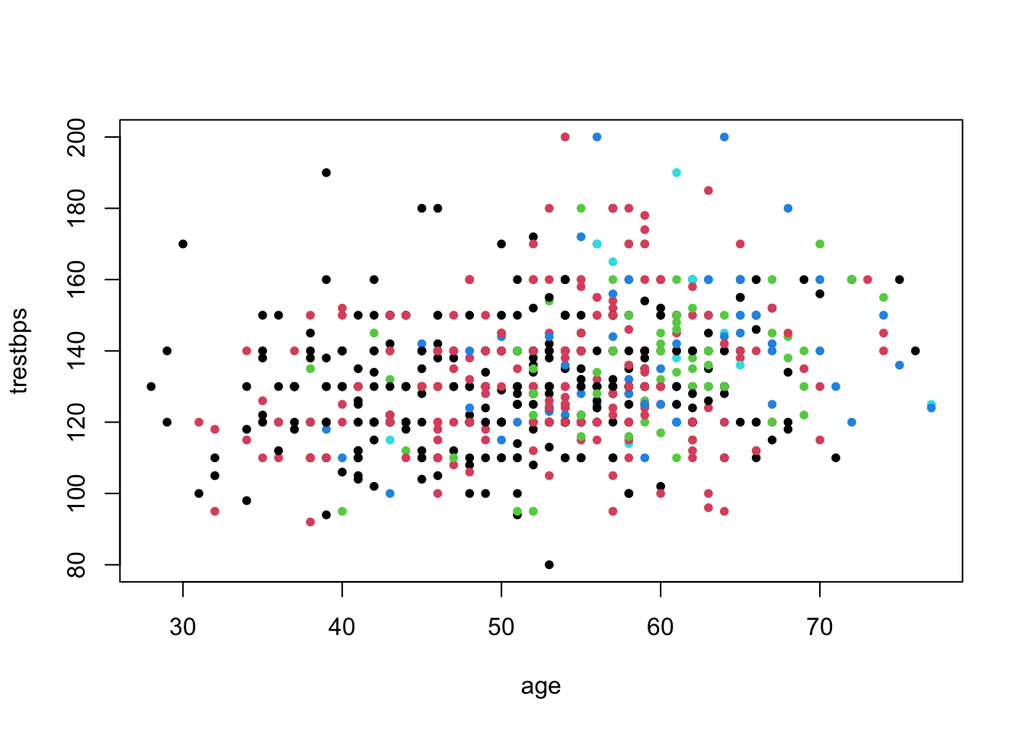

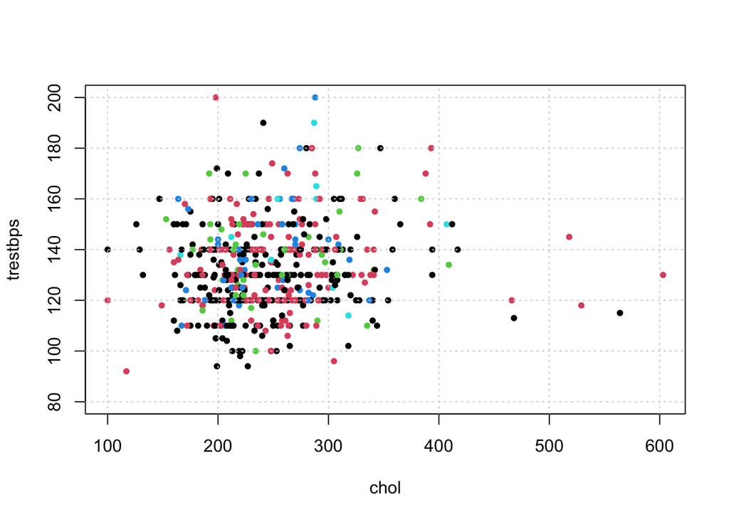

### Modeling

For my models, I first established a baseline (i.e. what would happen if I just always predicted no heart disease) in order to learn what a “good” accuracy rate would be for my final model. As can be seen from the below chunk, if we always predict that a patient has no heart disease, we can attain ~52% accuracy. Thus, we want our final model to perform significantly better than this baseline.

```r
# estimation-validation split of data
set.seed(42)
est_idx = createDataPartition(trn_omit$res, p = 0.80, list = TRUE)
est = trn_omit[est_idx$Resample1, ]
val = trn_omit[-est_idx$Resample1, ]

# what happens if we always say no?
table(
  actual = val$res,
  predicted = factor(rep(FALSE, length(val$res), levels=levels(val$res)))
)
```

```
##        predicted
## actual  FALSE
##   FALSE    55
##   TRUE     51
```

```r
# what is the baseline accuracy?
mean(rep(FALSE, length(val$res), levels=levels(val$res)) == val$res)
```

```
## [1] 0.5188679
```

Then, I compared a variety of different modeling techniques such as decision tress, KNN, and Stochastic Gradient Boosting with cross validation on both the all omitted dataset and partially omitted dataset.

```r
cv_5 = trainControl(method = "cv", number = 5)
knn_mod = train(form = res ~ ., data = est, method = "knn", trControl = cv_5)
tree_mod = train(form = res ~ ., data = est, method = "rpart", trControl = cv_5)
gbm_mod = train(form = res ~ ., data = est, method = "gbm", trControl = cv_5)
```

```r
mean(predict(knn_mod, newdata = val, type = "raw") == val$res)
```

```
## [1] 0.5471698
```

```r
mean(predict(tree_mod, newdata = val, type = "raw") == val$res)
```

```
## [1] 0.6886792
```

```r
mean(predict(gbm_mod, newdata = val, type = "raw") == val$res)
```

```
## [1] 0.745283
```

## Results

```
## Confusion Matrix and Statistics
##
##           Reference
## Prediction FALSE TRUE
##      FALSE    33    6
##      TRUE      8   44
##
##                Accuracy : 0.8462
##                  95% CI : (0.7554, 0.9133)
##     No Information Rate : 0.5495
##     P-Value [Acc > NIR] : 1.82e-09
##
##                   Kappa : 0.6879
##
##  Mcnemar's Test P-Value : 0.7893
##
##             Sensitivity : 0.8049
##             Specificity : 0.8800
##          Pos Pred Value : 0.8462
##          Neg Pred Value : 0.8462
##              Prevalence : 0.4505
##          Detection Rate : 0.3626
##    Detection Prevalence : 0.4286
##       Balanced Accuracy : 0.8424
##
##        'Positive' Class : FALSE
##
```

## Appendix

Below is all the code I utilized to complete my analysis.

```r
# load packages
library("tidyverse")
library("caret")
library("rpart")
library("rpart.plot")

# read in the data
hd = read_csv("data/hd.csv")
hd$res = ifelse(hd$num != "v0", TRUE, FALSE)

# test-train split data
trn_idx = createDataPartition(hd$num, p = 0.80, list = TRUE)
trn = hd[trn_idx$Resample1,]
tst = hd[-trn_idx$Resample1,]


# feature engineering
trn$num = factor(trn$num)
trn$res = factor(trn$res)
trn$location = factor(trn$location)
trn$cp = factor(trn$cp)
trn$sex = factor(trn$sex)
trn$fbs = factor(trn$fbs)
trn$restecg = factor(trn$restecg)
trn$exang = factor(trn$exang)
trn[which(trn$chol == 0),]$chol = NA

tst$num = factor(tst$num)
tst$res = factor(tst$res)
tst$location = factor(tst$location)
tst$cp = factor(tst$cp)
tst$sex = factor(tst$sex)
tst$fbs = factor(tst$fbs)
tst$restecg = factor(tst$restecg)
tst$exang = factor(tst$exang)
tst[which(tst$chol == 0),]$chol = NA


# function to determine proportion of NAs in a vector
na_prop = function(x) {
  mean(is.na(x))
}


# check proportion of NAs in each column
sapply(trn, na_prop)

# look at data
skimr::skim(trn)


# starting exploratory analysis
plot(trestbps ~ age, trn, pch = 20, col = trn$num)
grid()


# can we fit a model? yes!
rpart(num ~ ., data = trn)


#######################################################################################################
# remove any observation with NA
trn_full = na.omit(trn)


# estimation-validation split of data
set.seed(42)
est_idx = createDataPartition(trn_full$num, p = 0.80, list = TRUE)
est = trn_full[est_idx$Resample1, ]
val = trn_full[-est_idx$Resample1, ]


# looking at response in estimation data
table(est$num)


# what happens if we always say no?
table(
  actual = val$num,
  predicted = factor(rep("v0", length(val$num), levels=levels(val$num)))
)


# fit first model
mod = rpart(num ~ ., data = est)
rpart.plot(mod)


# model baseline
table(
  actual = val$num,
  predicted = predict(mod, val, type = "class")
)


# calculate baseline accuracy
mean(predict(mod, val, type = "class") == val$num)


#######################################################################################################
# remove any observation with NA
trn_full = na.omit(trn)


# classification
cv_5 = trainControl(method = "cv", number = 5)
tree_mod = train(form = num ~ ., data = trn_full, method = "rpart", trControl = cv_5) # good
knn_mod = train(form = num ~ ., data = trn_full, method = "knn", trControl = cv_5)
gbm_mod = train(form = num ~ ., data = trn_full, method = "gbm", trControl = cv_5) # good


#######################################################################################################
# remove any observation with NA
trn_full = na.omit(trn)
trn_full = subset(trn_full, select = -c(num))


# binary response
cv_5 = trainControl(method = "cv", number = 5)
tree_mod = train(form = res ~ ., data = trn_full, method = "rpart", trControl = cv_5) # good
gbm_mod = train(form = res ~ ., data = trn_full, method = "gbm", trControl = cv_5) # good


#######################################################################################################
# modify dataset without columns containing more than 33% NAs
# Note: trn$fbs has a significant number of NAs -- keep in mind that most data points are no
trn_omit = na.omit(trn[, !sapply(trn, na_prop) > 0.33])
trn_omit = subset(trn_omit, select = -c(num))


# binary response
cv_5 = trainControl(method = "cv", number = 5)
tree_mod = train(form = res ~ ., data = trn_omit, method = "rpart", trControl = cv_5) # good
gbm_mod = train(form = res ~ ., data = trn_omit, method = "gbm", trControl = cv_5) # good


#######################################################################################################
# modify dataset without columns containing more than 33% NAs
# Note: trn$fbs has a significant number of NAs -- keep in mind that most data points are no
trn_omit = na.omit(trn[, !sapply(trn, na_prop) > 0.33])
trn_omit = subset(trn_omit, select = -c(num))


# estimation-validation split of data
set.seed(42)
est_idx = createDataPartition(trn_omit$res, p = 0.80, list = TRUE)
est = trn_omit[est_idx$Resample1, ]
val = trn_omit[-est_idx$Resample1, ]

# binary response
cv_5 = trainControl(method = "cv", number = 5)
gbm_mod = train(form = res ~ ., data = est, method = "gbm", trControl = cv_5) # good


# calculate validation accuracy
print(mean(predict(gbm_mod, val, type = "raw") == val$res))


# train on full train set
gbm_mod_official = train(form = res ~ ., data = trn_omit, method = "gbm", trControl = cv_5) # good


# omit in tst data as well
tst_omit = na.omit(tst[, !sapply(tst, na_prop) > 0.33])
tst_omit = subset(tst_omit, select = -c(num))


# calculate test accuracy
preds = predict(gbm_mod_official, newdata = tst_omit, type = "raw")
print(mean(preds == tst_omit$res))


# confusion matrix
confusionMatrix(preds, tst_omit$res)
```